# Binary-Class Tabular Model for Pumpkin Seeds Identification Using Python and AutoKeras

### September 21, 2022

SUMMARY: The project aims to construct a predictive model using various machine learning algorithms and document the end-to-end steps using a template. The Pumpkin Seeds Identification dataset is a binary-class modeling situation where we attempt to predict one of two possible outcomes.

INTRODUCTION: Pumpkin seeds are frequently consumed as confection worldwide because of their adequate amount of protein, fat, carbohydrate, and mineral contents. The research team carried out a study on the two most important types of pumpkin seed, “Ürgüp Sivrisi” and “Çerçevelik,” generally grown in Ürgüp and Karacaören regions in Turkey. Furthermore, the morphological measurements of 2500 pumpkin seeds of both varieties were captured using the gray and binary forms of threshold techniques.

CONCLUSION: In this iteration, AutoKeras appeared to be a suitable algorithm for modeling this dataset.

Dataset Used: Pumpkin Seeds Dataset

Dataset ML Model: Binary classification with numerical features

Dataset Reference: https://www.muratkoklu.com/datasets/

One source of potential performance benchmarks: https://doi.org/10.1007/s10722-021-01226-0

## Task 1 - Prepare Environment

```python
# Install TensorFlow Decision Forests.
!pip install autokeras
```

```
     |████████████████████████████████| 162 kB 13.6 MB/s
     |████████████████████████████████| 135 kB 70.0 MB/s
     |████████████████████████████████| 1.6 MB 68.3 MB/s
```

```python
# Retrieve the GPU information
gpu_info = !nvidia-smi
gpu_info = '\n'.join(gpu_info)
print(gpu_info)
```

```
Thu Sep 15 15:32:30 2022
+-----------------------------------------------------------------------------+
| NVIDIA-SMI 460.32.03    Driver Version: 460.32.03    CUDA Version: 11.2     |
|-------------------------------+----------------------+----------------------+
| GPU  Name        Persistence-M| Bus-Id        Disp.A | Volatile Uncorr. ECC |
| Fan  Temp  Perf  Pwr:Usage/Cap|         Memory-Usage | GPU-Util  Compute M. |
|                               |                      |               MIG M. |
|===============================+======================+======================|
|   0  Tesla V100-SXM2...  Off  | 00000000:00:04.0 Off |                    0 |
| N/A   36C    P0    23W / 300W |      0MiB / 16160MiB |      0%      Default |
|                               |                      |                  N/A |
+-------------------------------+----------------------+----------------------+

+-----------------------------------------------------------------------------+
| Processes:                                                                  |
|  GPU   GI   CI        PID   Type   Process name                  GPU Memory |
|        ID   ID                                                   Usage      |
|=============================================================================|
|  No running processes found                                                 |
+-----------------------------------------------------------------------------+
```

```python
# Retrieve the memory configuration
from psutil import virtual_memory
ram_gb = virtual_memory().total / 1e9
print('Your runtime has {:.1f} gigabytes of available RAM\n'.format(ram_gb))
```

```
Your runtime has 13.6 gigabytes of available RAM
```

```python
# Retrieve the CPU information
ncpu = !nproc
print("The number of available CPUs is:", ncpu[0])
```

```
The number of available CPUs is: 2
```

### 1.a) Load libraries and modules

```python
# Set the random seed number for reproducible results
RNG_SEED = 888
```

```python
import random
random.seed(RNG_SEED)
import numpy as np
np.random.seed(RNG_SEED)
import pandas as pd
import seaborn as sns
import matplotlib.pyplot as plt
import os
import sys
import math
# import boto3
import zipfile
from datetime import datetime
from sklearn import preprocessing
from sklearn.model_selection import train_test_split
from sklearn.model_selection import RepeatedKFold
from sklearn.model_selection import cross_val_score
from sklearn.metrics import classification_report
from sklearn.metrics import confusion_matrix
from sklearn.metrics import accuracy_score
from sklearn.pipeline import Pipeline
from sklearn import compose
from sklearn import impute

# from sklearn.feature_selection import RFE
# from imblearn.pipeline import Pipeline
# from imblearn.over_sampling import SMOTE
# from imblearn.under_sampling import RandomUnderSampler

import tensorflow as tf
tf.random.set_seed(RNG_SEED)
import keras_tuner
import autokeras as ak
```

### 1.b) Set up the controlling parameters and functions

```python
# Begin the timer for the script processing
START_TIME_SCRIPT = datetime.now()
```

```python
# Set up the number of CPU cores available for multi-thread processing
N_JOBS = 1

# Set up the flag to stop sending progress emails (setting to True will send status emails!)
NOTIFY_STATUS = False

# Set the percentage sizes for splitting the dataset
TEST_SET_RATIO = 0.2
VAL_SET_RATIO = 0.1

# Set the name for the class/label column
ORIGINAL_LABEL = 'Class'
CLASS_COLUMN = 'target'

# Set the number of folds for cross validation
N_FOLDS = 10
N_ITERATIONS = 1

# Set various default modeling parameters
DEFAULT_LOSS = 'binary_crossentropy'
DEFAULT_METRICS = ['accuracy']
DEFAULT_OPTIMIZER = tf.keras.optimizers.Adam(learning_rate=0.0001)
CLASSIFIER_ACTIVATION = 'sigmoid'
MAX_EPOCHS = 10
BATCH_SIZE = 32
NUM_CLASSES = 1
MAX_TRIALS = 100

# Define the labels to use for graphing the data
TRAIN_METRIC = "accuracy"
VALIDATION_METRIC = "val_accuracy"
TRAIN_LOSS = "loss"
VALIDATION_LOSS = "val_loss"

# Define the directory locations and file names
TRAIN_DATASET = 'Pumpkin_Seeds_Dataset.arff'

# Check the number of GPUs accessible through TensorFlow
print('Num GPUs Available:', len(tf.config.list_physical_devices('GPU')))

# Print out the TensorFlow version for confirmation
print('TensorFlow version:', tf.__version__)
```

```
Num GPUs Available: 1
TensorFlow version: 2.8.2
```

```python
# Set up the email notification function
def status_notify(msg_text):
    access_key = os.environ.get('SNS_ACCESS_KEY')
    secret_key = os.environ.get('SNS_SECRET_KEY')
    aws_region = os.environ.get('SNS_AWS_REGION')
    topic_arn = os.environ.get('SNS_TOPIC_ARN')
    if (access_key is None) or (secret_key is None) or (aws_region is None):
        sys.exit("Incomplete notification setup info. Script Processing Aborted!!!")
    sns = boto3.client('sns', aws_access_key_id=access_key, aws_secret_access_key=secret_key, region_name=aws_region)
    response = sns.publish(TopicArn=topic_arn, Message=msg_text)
    if response['ResponseMetadata']['HTTPStatusCode'] != 200 :
        print('Status notification not OK with HTTP status code:', response['ResponseMetadata']['HTTPStatusCode'])
```

```python
if NOTIFY_STATUS: status_notify("Task 1 - Prepare Environment has begun! " + datetime.now().strftime('%a %B %d, %Y %I:%M:%S %p'))
```

### 1.c) Load dataset

```python
dataset_path = 'https://dainesanalytics.com/datasets/muratkoklu-pumpkin-seeds-dataset/Pumpkin_Seeds_Dataset.arff'
colNames = ['Area','Perimeter','Major_Axis_Length','Minor_Axis_Length','Convex_Area',
            'Equiv_Diameter','Eccentricity','Solidity','Extent','Roundness',
            'Aspect_Ratio','Compactness','Class']
df_dataset_import = pd.read_csv(dataset_path, names=colNames, sep=',', header=None, index_col=False, skiprows=24)

# Take a peek at the dataframe after import
print(df_dataset_import.head())
```

```
    Area  Perimeter  Major_Axis_Length  Minor_Axis_Length  Convex_Area  \
0  56276    888.242           326.1485           220.2388        56831
1  76631   1068.146           417.1932           234.2289        77280
2  71623   1082.987           435.8328           211.0457        72663
3  66458    992.051           381.5638           222.5322        67118
4  66107    998.146           383.8883           220.4545        67117

   Equiv_Diameter  Eccentricity  Solidity  Extent  Roundness  Aspect_Ratio  \
0        267.6805        0.7376    0.9902  0.7453     0.8963        1.4809
1        312.3614        0.8275    0.9916  0.7151     0.8440        1.7811
2        301.9822        0.8749    0.9857  0.7400     0.7674        2.0651
3        290.8899        0.8123    0.9902  0.7396     0.8486        1.7146
4        290.1207        0.8187    0.9850  0.6752     0.8338        1.7413

   Compactness       Class
0       0.8207  CERCEVELIK
1       0.7487  CERCEVELIK
2       0.6929  CERCEVELIK
3       0.7624  CERCEVELIK
4       0.7557  CERCEVELIK
```

```python
df_dataset_import.info(verbose=True)
```

```
<class 'pandas.core.frame.DataFrame'>
RangeIndex: 2500 entries, 0 to 2499
Data columns (total 13 columns):
 #   Column             Non-Null Count  Dtype
---  ------             --------------  -----
 0   Area               2500 non-null   int64
 1   Perimeter          2500 non-null   float64
 2   Major_Axis_Length  2500 non-null   float64
 3   Minor_Axis_Length  2500 non-null   float64
 4   Convex_Area        2500 non-null   int64
 5   Equiv_Diameter     2500 non-null   float64
 6   Eccentricity       2500 non-null   float64
 7   Solidity           2500 non-null   float64
 8   Extent             2500 non-null   float64
 9   Roundness          2500 non-null   float64
 10  Aspect_Ratio       2500 non-null   float64
 11  Compactness        2500 non-null   float64
 12  Class              2500 non-null   object
dtypes: float64(10), int64(2), object(1)
memory usage: 254.0+ KB
```

```python
print(df_dataset_import.describe())
```

```
                Area    Perimeter  Major_Axis_Length  Minor_Axis_Length  \
count    2500.000000  2500.000000        2500.000000        2500.000000
mean    80658.220800  1130.279015         456.601840         225.794921
std     13664.510228   109.256418          56.235704          23.297245
min     47939.000000   868.485000         320.844600         152.171800
25%     70765.000000  1048.829750         414.957850         211.245925
50%     79076.000000  1123.672000         449.496600         224.703100
75%     89757.500000  1203.340500         492.737650         240.672875
max    136574.000000  1559.450000         661.911300         305.818000

         Convex_Area  Equiv_Diameter  Eccentricity     Solidity       Extent  \
count    2500.000000     2500.000000   2500.000000  2500.000000  2500.000000
mean    81508.084400      319.334230      0.860879     0.989492     0.693205
std     13764.092788       26.891920      0.045167     0.003494     0.060914
min     48366.000000      247.058400      0.492100     0.918600     0.468000
25%     71512.000000      300.167975      0.831700     0.988300     0.658900
50%     79872.000000      317.305350      0.863700     0.990300     0.713050
75%     90797.750000      338.057375      0.897025     0.991500     0.740225
max    138384.000000      417.002900      0.948100     0.994400     0.829600

         Roundness  Aspect_Ratio  Compactness
count  2500.000000   2500.000000  2500.000000
mean      0.791533      2.041702     0.704121
std       0.055924      0.315997     0.053067
min       0.554600      1.148700     0.560800
25%       0.751900      1.801050     0.663475
50%       0.797750      1.984200     0.707700
75%       0.834325      2.262075     0.743500
max       0.939600      3.144400     0.904900
```

```python
print(df_dataset_import.isnull().sum())
print('Total number of NaN in the dataframe: ', df_dataset_import.isnull().sum().sum())
```

```
Area                 0
Perimeter            0
Major_Axis_Length    0
Minor_Axis_Length    0
Convex_Area          0
Equiv_Diameter       0
Eccentricity         0
Solidity             0
Extent               0
Roundness            0
Aspect_Ratio         0
Compactness          0
Class                0
dtype: int64
Total number of NaN in the dataframe:  0
```

```python
# Get grouping size for the target variable
print(df_dataset_import.groupby(ORIGINAL_LABEL).size())
```

```
Class
CERCEVELIK       1300
URGUP_SIVRISI    1200
dtype: int64
```

### 1.d) Data Cleaning

```python
# Standardize the class column to the name of targetVar if required
df_dataset_import = df_dataset_import.rename(columns={ORIGINAL_LABEL: CLASS_COLUMN})

# Take a peek at the dataframe after cleaning
print(df_dataset_import.head())
```

```
    Area  Perimeter  Major_Axis_Length  Minor_Axis_Length  Convex_Area  \
0  56276    888.242           326.1485           220.2388        56831
1  76631   1068.146           417.1932           234.2289        77280
2  71623   1082.987           435.8328           211.0457        72663
3  66458    992.051           381.5638           222.5322        67118
4  66107    998.146           383.8883           220.4545        67117

   Equiv_Diameter  Eccentricity  Solidity  Extent  Roundness  Aspect_Ratio  \
0        267.6805        0.7376    0.9902  0.7453     0.8963        1.4809
1        312.3614        0.8275    0.9916  0.7151     0.8440        1.7811
2        301.9822        0.8749    0.9857  0.7400     0.7674        2.0651
3        290.8899        0.8123    0.9902  0.7396     0.8486        1.7146
4        290.1207        0.8187    0.9850  0.6752     0.8338        1.7413

   Compactness      target
0       0.8207  CERCEVELIK
1       0.7487  CERCEVELIK
2       0.6929  CERCEVELIK
3       0.7624  CERCEVELIK
4       0.7557  CERCEVELIK
```

```python
df_dataset_import.info(verbose=True)
```

```
<class 'pandas.core.frame.DataFrame'>
RangeIndex: 2500 entries, 0 to 2499
Data columns (total 13 columns):
 #   Column             Non-Null Count  Dtype
---  ------             --------------  -----
 0   Area               2500 non-null   int64
 1   Perimeter          2500 non-null   float64
 2   Major_Axis_Length  2500 non-null   float64
 3   Minor_Axis_Length  2500 non-null   float64
 4   Convex_Area        2500 non-null   int64
 5   Equiv_Diameter     2500 non-null   float64
 6   Eccentricity       2500 non-null   float64
 7   Solidity           2500 non-null   float64
 8   Extent             2500 non-null   float64
 9   Roundness          2500 non-null   float64
 10  Aspect_Ratio       2500 non-null   float64
 11  Compactness        2500 non-null   float64
 12  target             2500 non-null   object
dtypes: float64(10), int64(2), object(1)
memory usage: 254.0+ KB
```

```python
print(df_dataset_import.describe())
```

```
                Area    Perimeter  Major_Axis_Length  Minor_Axis_Length  \
count    2500.000000  2500.000000        2500.000000        2500.000000
mean    80658.220800  1130.279015         456.601840         225.794921
std     13664.510228   109.256418          56.235704          23.297245
min     47939.000000   868.485000         320.844600         152.171800
25%     70765.000000  1048.829750         414.957850         211.245925
50%     79076.000000  1123.672000         449.496600         224.703100
75%     89757.500000  1203.340500         492.737650         240.672875
max    136574.000000  1559.450000         661.911300         305.818000

         Convex_Area  Equiv_Diameter  Eccentricity     Solidity       Extent  \
count    2500.000000     2500.000000   2500.000000  2500.000000  2500.000000
mean    81508.084400      319.334230      0.860879     0.989492     0.693205
std     13764.092788       26.891920      0.045167     0.003494     0.060914
min     48366.000000      247.058400      0.492100     0.918600     0.468000
25%     71512.000000      300.167975      0.831700     0.988300     0.658900
50%     79872.000000      317.305350      0.863700     0.990300     0.713050
75%     90797.750000      338.057375      0.897025     0.991500     0.740225
max    138384.000000      417.002900      0.948100     0.994400     0.829600

         Roundness  Aspect_Ratio  Compactness
count  2500.000000   2500.000000  2500.000000
mean      0.791533      2.041702     0.704121
std       0.055924      0.315997     0.053067
min       0.554600      1.148700     0.560800
25%       0.751900      1.801050     0.663475
50%       0.797750      1.984200     0.707700
75%       0.834325      2.262075     0.743500
max       0.939600      3.144400     0.904900
```

```python
print(df_dataset_import.isnull().sum())
print('Total number of NaN in the dataframe: ', df_dataset_import.isnull().sum().sum())
```

```
Area                 0
Perimeter            0
Major_Axis_Length    0
Minor_Axis_Length    0
Convex_Area          0
Equiv_Diameter       0
Eccentricity         0
Solidity             0
Extent               0
Roundness            0
Aspect_Ratio         0
Compactness          0
target               0
dtype: int64
Total number of NaN in the dataframe:  0
```

```python
# Get grouping size for the target variable
print(df_dataset_import.groupby(CLASS_COLUMN).size())
```

```
target
CERCEVELIK       1300
URGUP_SIVRISI    1200
dtype: int64
```

### 1.e) Splitting Data into Sets

```python
# Use variable total_column_count to hold the number of columns in the dataframe
total_column_count = len(df_dataset_import.columns)

# Set up variable total_feature_count for the total number of attribute columns
total_feature_count = total_column_count-1

# We create attribute-only and target-only datasets (df_features_train and df_target_train)
df_target_train = df_dataset_import['target']
df_features_train = df_dataset_import.drop(['target'], axis=1)

print("df_dataset_import.shape: {} df_features_train.shape: {} df_target_train.shape: {}".format(df_dataset_import.shape, df_features_train.shape, df_target_train.shape))
```

```
df_dataset_import.shape: (2500, 13) df_features_train.shape: (2500, 12) df_target_train.shape: (2500,)
```

### 1.f) Set up the parameters for data visualization

```python
# Set up the number of row and columns for visualization display. display_rows * display_columns should be >= total_feature_count
display_columns = 4
if total_feature_count % display_columns == 0 :
    display_rows = total_feature_count // display_columns
else :
    display_rows = (total_feature_count // display_columns) + 1

# Set figure width to display the data visualization plots
fig_size = plt.rcParams["figure.figsize"]
fig_size[0] = display_columns * 4
fig_size[1] = display_rows * 4
plt.rcParams["figure.figsize"] = fig_size
```

```python
if NOTIFY_STATUS: status_notify("Task 1 - Prepare Environment completed! " + datetime.now().strftime('%a %B %d, %Y %I:%M:%S %p'))
```

## Task 2 - Summarize and Visualize Data

```python
if NOTIFY_STATUS: status_notify("Task 2 - Summarize and Visualize Data has begun! " + datetime.now().strftime('%a %B %d, %Y %I:%M:%S %p'))
```

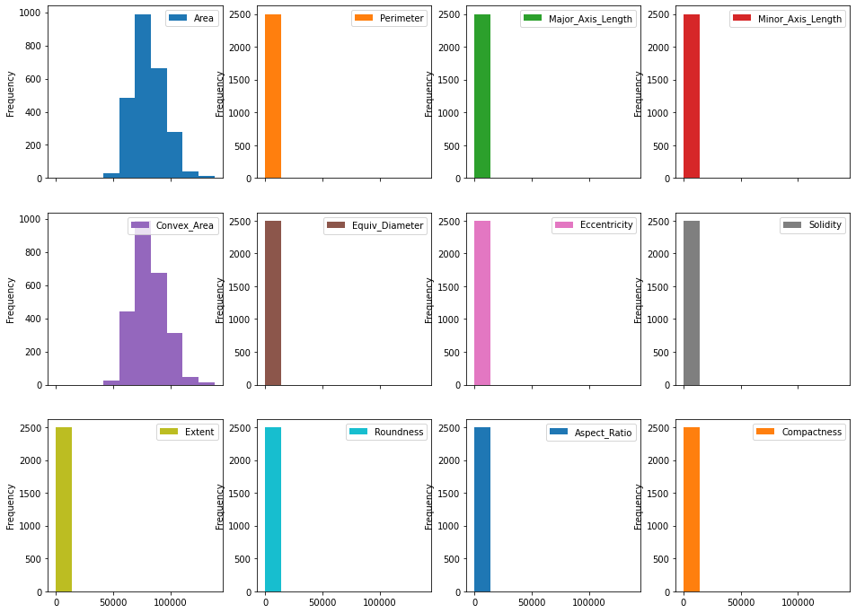

```python
# Histograms for each attribute
df_features_train.plot(kind='hist', subplots=True, layout=(display_rows, display_columns))
plt.show()
```

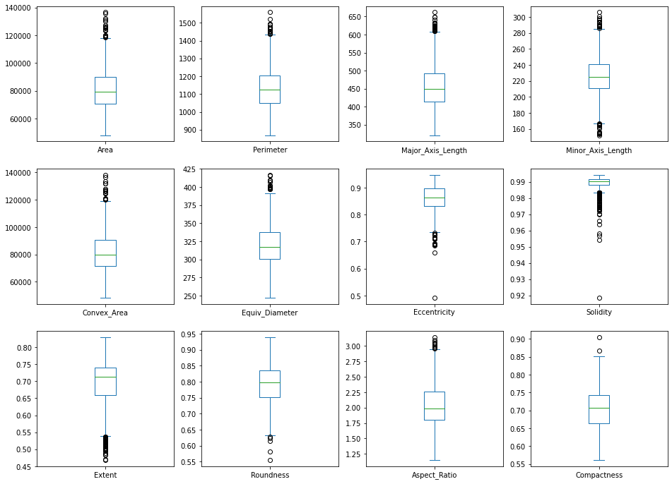

```python
# Box and Whisker plot for each attribute
df_features_train.plot(kind='box', subplots=True, layout=(display_rows, display_columns))
plt.show()
```

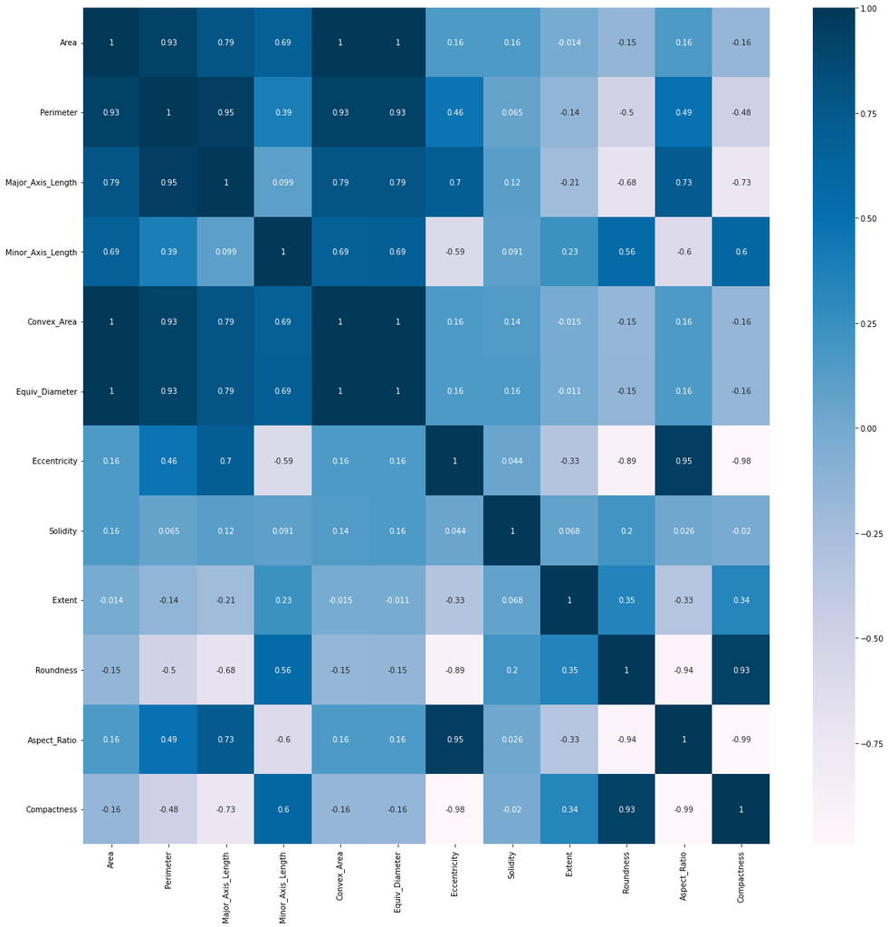

```python
# Correlation matrix
fig = plt.figure(figsize=(20, 20))
correlations = df_features_train.corr(method='pearson')
sns.heatmap(correlations, annot=True, cmap=plt.cm.PuBu)
plt.show()
```

```python
if NOTIFY_STATUS: status_notify("Task 2 - Summarize and Visualize Data completed! " + datetime.now().strftime('%a %B %d, %Y %I:%M:%S %p'))
```

## Task 3 - Pre-process Data

```python
if NOTIFY_STATUS: status_notify("Task 3 - Pre-process Data has begun! " + datetime.now().strftime('%a %B %d, %Y %I:%M:%S %p'))
```

### 3.a) Feature Scaling

```python
# Compose pipeline for the numerical and categorical features (Block #1 of 2)
numeric_columns = df_features_train.select_dtypes(include=['int64','float64']).columns
numeric_transformer = Pipeline(steps=[
    ('imputer', impute.SimpleImputer(strategy="constant", fill_value=0)),
    ('scaler', preprocessing.MinMaxScaler())
])
categorical_columns = df_features_train.select_dtypes(include=['object','bool','category']).columns
categorical_transformer = Pipeline(steps=[
    ('imputer', impute.SimpleImputer(strategy='constant', fill_value='UKNOWN')),
    ('onehot', preprocessing.OneHotEncoder(sparse=False, handle_unknown='ignore'))
])

print("Number of numerical columns:", len(numeric_columns))
print("Number of categorical columns:", len(categorical_columns))
print("Total number of columns in the feature dataframe:", df_features_train.shape[1])
```

```
Number of numerical columns: 12
Number of categorical columns: 0
Total number of columns in the feature dataframe: 12
```

```python
# Compose pipeline for the numerical and categorical features (Block #2 of 2)
preprocessor = compose.ColumnTransformer(transformers=[
    ('num', numeric_transformer, numeric_columns),
    ('cat', categorical_transformer, categorical_columns)
])

# Display the shapes of the training dataset for final inspection
array_features_train = preprocessor.fit_transform(df_features_train)
print("Transformed features from df_features_train.shape: {} to array_features_train.shape: {}".format(df_features_train.shape, array_features_train.shape))
```

```
Transformed features from df_features_train.shape: (2500, 12) to array_features_train.shape: (2500, 12)
```

### 3.b) Training Data Balancing

```python
# Not applicable for this iteration of the project
```

### 3.c) Feature Selection

```python
# Not applicable for this iteration of the project
```

### 3.d) Display the Final Datasets for Model-Building

```python
# Finalize the training dataset for the modeling activities
label_encoder = preprocessing.LabelEncoder()
# array_target_train = keras.utils.to_categorical(label_encoder.fit_transform(df_target_train))
array_target_train = label_encoder.fit_transform(df_target_train)
print("array_features_train.shape: {} array_target_train.shape: {}".format(array_features_train.shape, array_target_train.shape))
```

```
array_features_train.shape: (2500, 12) array_target_train.shape: (2500,)
```

```python
if NOTIFY_STATUS: status_notify("Task 3 - Pre-process Data completed! " + datetime.now().strftime('%a %B %d, %Y %I:%M:%S %p'))
```

## Task 4 - Train and Tune Models

```python
if NOTIFY_STATUS: status_notify("Task 4 - Train and Tune Models has begun! " + datetime.now().strftime('%a %B %d, %Y %I:%M:%S %p'))
```

### 4.a) Set test options and evaluation metric

```python
start_time_module = datetime.now()
tf.keras.utils.set_random_seed(RNG_SEED)
auto_model = ak.StructuredDataClassifier(loss=DEFAULT_LOSS,
                                         metrics=DEFAULT_METRICS,
                                         max_trials=MAX_TRIALS,
                                         objective=keras_tuner.Objective("loss", direction="min"),
                                         seed=RNG_SEED)
auto_model.fit(x=array_features_train,
               y=array_target_train,
               epochs=MAX_EPOCHS,
               batch_size=BATCH_SIZE)
print('Total time for model fitting:', (datetime.now() - start_time_module))
```

```
Trial 64 Complete [00h 00m 06s]
loss: 0.5529176592826843

Best loss So Far: 0.26605698466300964
Total elapsed time: 00h 06m 46s
Total time for model fitting: 0:06:58.690987
```

```python
if NOTIFY_STATUS: status_notify("Task 4 - Train and Tune Models completed! " + datetime.now().strftime('%a %B %d, %Y %I:%M:%S %p'))
```

## Task 5 - Finalize Model and Make Predictions

```python
if NOTIFY_STATUS: status_notify("Task 5 - Finalize Model and Make Predictions has begun! " + datetime.now().strftime('%a %B %d, %Y %I:%M:%S %p'))
```

```python
tf.keras.utils.set_random_seed(RNG_SEED)
final_model = auto_model.export_model()
final_model.summary()
```

```
Model: "model"
_________________________________________________________________
 Layer (type)                Output Shape              Param #
=================================================================
 input_1 (InputLayer)        [(None, 12)]              0

 multi_category_encoding (Mu  (None, 12)               0
 ltiCategoryEncoding)

 normalization (Normalizatio  (None, 12)               25
 n)

 dense (Dense)               (None, 32)                416

 re_lu (ReLU)                (None, 32)                0

 dense_1 (Dense)             (None, 1024)              33792

 re_lu_1 (ReLU)              (None, 1024)              0

 dense_2 (Dense)             (None, 1)                 1025

 classification_head_1 (Acti  (None, 1)                0
 vation)

=================================================================
Total params: 35,258
Trainable params: 35,233
Non-trainable params: 25
_________________________________________________________________
```

```python
if NOTIFY_STATUS: status_notify("Task 5 - Finalize Model and Make Predictions completed! " + datetime.now().strftime('%a %B %d, %Y %I:%M:%S %p'))
```

```python
print ('Total time for the script:',(datetime.now() - START_TIME_SCRIPT))
```

```
Total time for the script: 0:07:07.483887
```